# Telco_Customer_clasyfication_ML

Orginal data set: https://www.kaggle.com/code/emineyetm/telco-customer-churn/notebook

Author of dataset: https://www.kaggle.com/emineyetm

```
<class 'pandas.core.frame.DataFrame'>
RangeIndex: 7043 entries, 0 to 7042
Data columns (total 18 columns):
 #   Column            Non-Null Count  Dtype
---  ------            --------------  -----
 0   gender            7043 non-null   object
 1   SeniorCitizen     7043 non-null   int64
 2   Partner           7043 non-null   object
 3   Dependents        7043 non-null   object
 4   tenure            7043 non-null   int64
 5   MultipleLines     7043 non-null   object
 6   InternetService   7043 non-null   object
 7   OnlineSecurity    7043 non-null   object
 8   OnlineBackup      7043 non-null   object
 9   DeviceProtection  7043 non-null   object
 10  TechSupport       7043 non-null   object
 11  StreamingTV       7043 non-null   object
 12  StreamingMovies   7043 non-null   object
 13  Contract          7043 non-null   object
 14  PaperlessBilling  7043 non-null   object
 15  PaymentMethod     7043 non-null   object
 16  MonthlyCharges    7043 non-null   float64
 17  Churn             7043 non-null   object
dtypes: float64(1), int64(2), object(15)
memory usage: 990.6+ KB
```

## 1 pyCaret

### 1.1 Setup

### 1.2 model selection

## Model Selection – Implications

#### 4. Business consequence

The ability to interpret model outputs is crucial for business decision-making, making simpler models more practical despite similar predictive performance.

# 3 Sci-kitlearn operatoion

### 3.1. X/Y division

### 3.2. Target encoding

### 3.3. feature encoding

✔️ binary (Yes/No) 'Partner', 'Dependents', 'PaperlessBilling'

✔️ One-Hot else remains

### 3.4. Train / test split

### 3.5. First model (baseline)

```
LogisticRegression(max_iter=1000)
```

### 3.6. Predyction

### 3.7. Assessment

```
              precision    recall  f1-score   support

           0       0.86      0.90      0.88      1036
           1       0.69      0.58      0.63       373

    accuracy                           0.82      1409
   macro avg       0.77      0.74      0.76      1409
weighted avg       0.81      0.82      0.81      1409
```

### The Logistic Regression model achieves an overall accuracy of 82%, but its ability to detect churn is limited, with a recall of only 58% for the churn class. This indicates that a significant portion of customers who are likely to leave are not correctly identified, which may limit the model's usefulness in a business context.

## 4. Improving actions:

1. class_weight (class_weight='balanced')
2. threshold tuning 0.5 → np. 0.3

1 - Probabilities

2 - Seting Threshold

```
Threshold: 0.5
              precision    recall  f1-score   support

           0       0.86      0.90      0.88      1036
           1       0.69      0.58      0.63       373

    accuracy                           0.82      1409
   macro avg       0.77      0.74      0.76      1409
weighted avg       0.81      0.82      0.81      1409


Threshold: 0.4
              precision    recall  f1-score   support

           0       0.88      0.84      0.86      1036
           1       0.61      0.68      0.64       373

    accuracy                           0.80      1409
   macro avg       0.74      0.76      0.75      1409
weighted avg       0.81      0.80      0.80      1409


Threshold: 0.3
              precision    recall  f1-score   support

           0       0.91      0.77      0.84      1036
           1       0.55      0.79      0.65       373

    accuracy                           0.78      1409
   macro avg       0.73      0.78      0.74      1409
weighted avg       0.82      0.78      0.79      1409


Threshold: 0.2
              precision    recall  f1-score   support

           0       0.93      0.65      0.77      1036
           1       0.47      0.87      0.61       373

    accuracy                           0.71      1409
   macro avg       0.70      0.76      0.69      1409
weighted avg       0.81      0.71      0.72      1409
```

## ROC curve

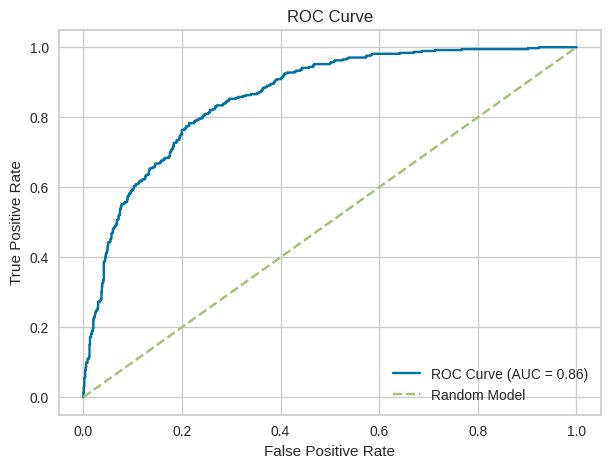

The ROC curve demonstrates that the model has strong discriminative ability, with an AUC of approximately 0.86, indicating good overall performance in distinguishing between churn and non-churn customers.

The curve represents the model's performance across all possible classification thresholds, highlighting the trade-off between true positive rate (recall) and false positive rate.

By adjusting the classification threshold, the model can be tuned to prioritize either higher recall (capturing more churn cases) or higher precision (reducing false positives).

In this analysis, thresholds in the range of 0.3–0.4 provide a reasonable balance, significantly improving churn detection while maintaining acceptable precision.

## 4. Final best model

#### Treshold = 0.4

#### - Why?

A threshold of 0.4 was selected as it provides a balanced trade-off between recall and precision. At this level, the model significantly improves the detection of churn cases compared to the default threshold (0.5), while keeping the number of false positives at an acceptable level. This balance is important from a business perspective, where identifying at-risk customers is valuable, but excessive false alerts may lead to inefficient resource allocation.

```
              precision    recall  f1-score   support

           0       0.88      0.84      0.86      1036
           1       0.61      0.68      0.64       373

    accuracy                           0.80      1409
   macro avg       0.74      0.76      0.75      1409
weighted avg       0.81      0.80      0.80      1409
```

### Top Features Influencing Churn (Logistic Regression)

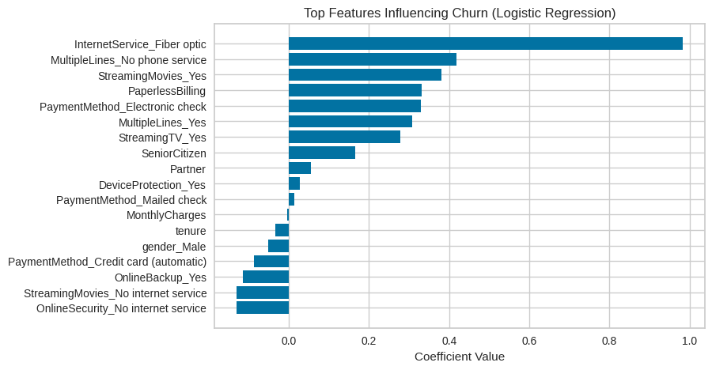

## 5. L1 model

### L1 regularization was applied to simplify the model by reducing the number of features, without impacting performance. The final model combines L1 regularization with a threshold of 0.4, resulting in improved churn detection and a more interpretable model.

```
LogisticRegression(C=0.5, max_iter=1000, penalty='l1', solver='liblinear')
```

### how many features does the model use

Number of features: 28

Non-zero features (in use): 27

### Feature Importance (L1 Logistic Regression)

|  | feature | coef |
| --- | --- | --- |
| 9 | InternetService_Fiber optic | 1.235744 |
| 22 | StreamingMovies_Yes | 0.479413 |
| 20 | StreamingTV_Yes | 0.373051 |
| 8 | MultipleLines_Yes | 0.347037 |
| 26 | PaymentMethod_Electronic check | 0.325101 |
| 4 | PaperlessBilling | 0.321637 |
| 7 | MultipleLines_No phone service | 0.178058 |
| 0 | SeniorCitizen | 0.159139 |
| 16 | DeviceProtection_Yes | 0.065553 |
| 1 | Partner | 0.035259 |
| 5 | MonthlyCharges | -0.014843 |
| 3 | tenure | -0.033011 |
| 13 | OnlineBackup_No internet service | -0.038028 |
| 6 | gender_Male | -0.044314 |
| 10 | InternetService_No | -0.047655 |
| 15 | DeviceProtection_No internet service | -0.049246 |
| 14 | OnlineBackup_Yes | -0.049647 |
| 11 | OnlineSecurity_No internet service | -0.052014 |
| 17 | TechSupport_No internet service | -0.052378 |
| 21 | StreamingMovies_No internet service | -0.054861 |
| 25 | PaymentMethod_Credit card (automatic) | -0.075621 |
| 2 | Dependents | -0.158850 |
| 18 | TechSupport_Yes | -0.244031 |
| 12 | OnlineSecurity_Yes | -0.328843 |
| 23 | Contract_One year | -0.623657 |
| 19 | StreamingTV_No internet service | -0.865737 |
| 24 | Contract_Two year | -1.358453 |

### Plot for Feature Importance (L1 Logistic Regression)

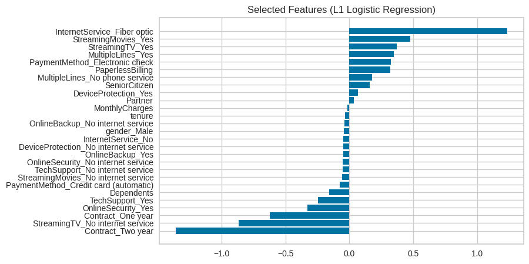

### Metric for Feature Importance (L1 Logistic Regression)

```
              precision    recall  f1-score   support

           0       0.86      0.91      0.88      1036
           1       0.69      0.58      0.63       373

    accuracy                           0.82      1409
   macro avg       0.78      0.75      0.76      1409
weighted avg       0.81      0.82      0.82      1409
```

# 6. Treshold 0.4 +L1

### Metric for Feature Importance (L1 Logistic Regression + Threshold 0.4)

```
              precision    recall  f1-score   support

           0       0.88      0.84      0.86      1036
           1       0.61      0.68      0.64       373

    accuracy                           0.80      1409
   macro avg       0.74      0.76      0.75      1409
weighted avg       0.81      0.80      0.80      1409
```

```
AUC (L1 model): 0.861
```

## Confusion matrix

```
[[873 163]
 [121 252]]
```

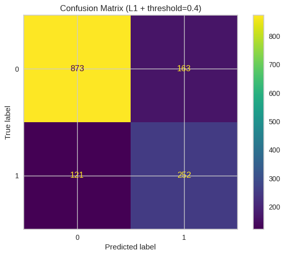

### The model correctly identifies 252 churn cases while missing 121, achieving a recall of ~68%. It also produces 163 false positives, indicating a moderate trade-off between detection rate and operational cost.

## ROC curve with Threshold 0.4

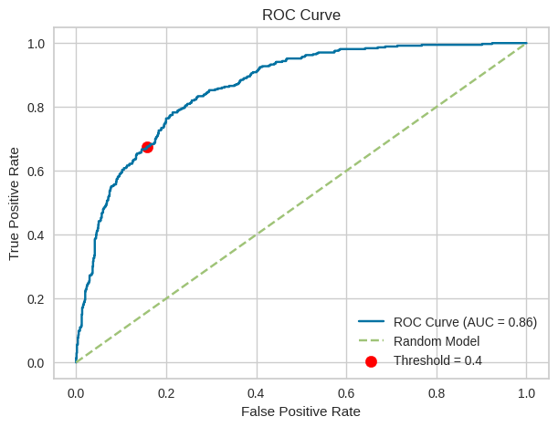

## By adjusting the classification threshold to 0.4 and applying L1 regularization, the model improved its ability to detect churn cases, increasing recall from 58% to 68%. Although this resulted in a slight decrease in precision and overall accuracy, the model is now more effective in identifying at-risk customers, which is more valuable from a business perspective.

# 🔥 6. Cross-Validation

```
AUC scores: [0.84533273 0.86695022 0.84756261 0.86725204 0.8474436  0.81958336
 0.83809307 0.8311112  0.83376948 0.8385275 ]
Mean AUC: 0.8435625826778257
```

#### Using 10-fold cross-validation, the model achieves AUC scores ranging from approximately 0.82 to 0.87, with a mean of 0.84. The relatively small variation across folds confirms that the model is stable and generalizes well, even under more rigorous validation.

# 7. Model Serialization

```
['clasyfication_model/churn_model_final.pkl']
```

## The final model is a Logistic Regression with L1 regularization, combined with a classification threshold of 0.4. This configuration provides a balance between model simplicity, interpretability, and improved churn detection performance.

# GradientBoostingClassifier

# ==============

## 1. Bild GradientBoostingClassifier model

```
GradientBoostingClassifier(random_state=42)
```

#### Both Logistic Regression and Gradient Boosting were evaluated on the same train-test split to ensure a fair performance comparison.

### 1.1 Mean Predicted Churn Probability

```
0.2705329489936074
```

### 1.2 ROC AUC for Gradient Boosting Classifier

```
ROC AUC: 0.861901829060006
```

A ROC AUC score of 0.86 suggests that the model performs well at distinguishing customers likely to churn from those likely to stay.

### 1.3 Default Threshold Evaluation

```
Recall: 0.5603217158176944
Precision: 0.6807817589576547
```

The model correctly identified around 56% of actual churn cases, while approximately 68% of predicted churn cases were correct.

### 1.4 Threshold Tuning

```
Threshold: 0.2
Recall: 0.882
Precision: 0.490
------------------------------
Threshold: 0.3
Recall: 0.802
Precision: 0.558
------------------------------
Threshold: 0.4
Recall: 0.681
Precision: 0.640
------------------------------
Threshold: 0.5
Recall: 0.560
Precision: 0.681
------------------------------
```

Different probability thresholds were evaluated to balance recall and precision. Lower thresholds increased recall but also produced a large number of false positives. Higher thresholds improved precision but reduced the model’s ability to detect actual churn cases.

A threshold of 0.4 provided the most balanced trade-off between recall and precision, maintaining solid churn detection performance while significantly reducing excessive false positive predictions.

### 1.3 Confusion matrix for every treshold

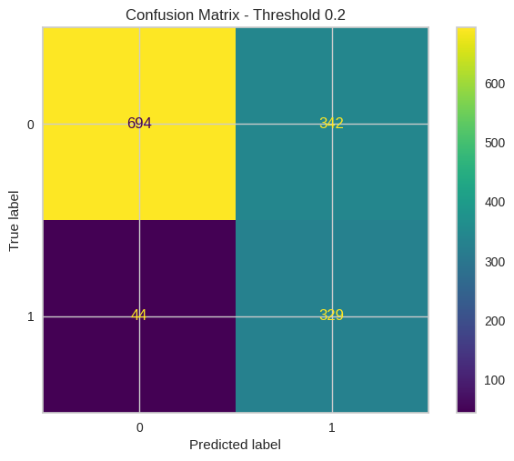

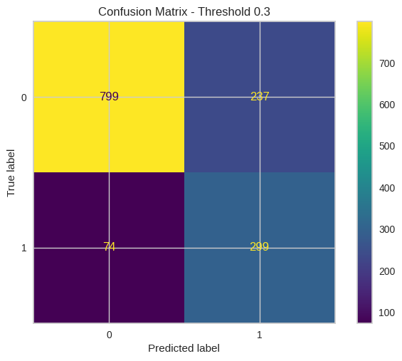

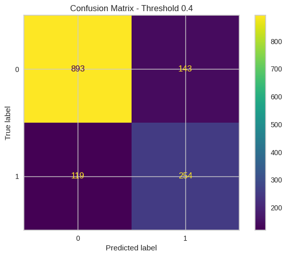

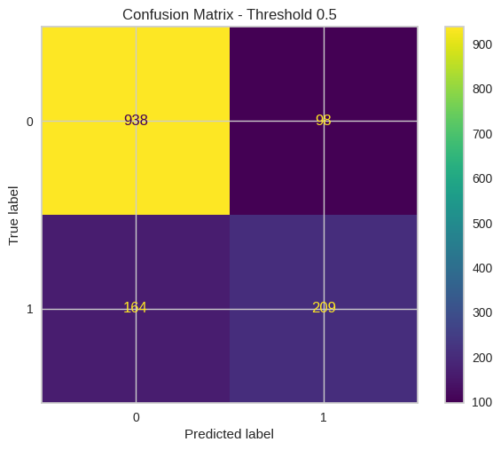

Lower thresholds improved churn detection but generated many false positives. Higher thresholds reduced false alarms at the cost of missing more actual churn cases.

Threshold 0.4 provided the most balanced business trade-off, maintaining strong churn detection performance while significantly reducing unnecessary churn predictions.

## 2 Tuning Gradient Boosting with learning rate

### 2.1 Tuning BG with learning_rate

```
Learning Rate: 0.01
ROC AUC: 0.8579
------------------------------
Learning Rate: 0.05
ROC AUC: 0.8639
------------------------------
Learning Rate: 0.1
ROC AUC: 0.8619
------------------------------
Learning Rate: 0.2
ROC AUC: 0.8582
------------------------------
```

Different learning rates were evaluated to analyze how aggressively the Gradient Boosting model updated its predictions during training.

Very small learning rates resulted in slightly lower performance, likely because the model learned too slowly with the default number of estimators. Higher learning rates also reduced ROC AUC, suggesting that overly aggressive updates harmed generalization performance.

A learning rate of 0.05 achieved the best ROC AUC score and provided the most stable balance between learning speed and model generalization.

### 2.2 Choseing learning rate 0.05

```
Learning Rate: 0.05
ROC AUC: 0.8639
```

## 3 Gradient Boosting model tuning with n_estimators

```
n_estimators: 50
ROC AUC: 0.8630
------------------------------
n_estimators: 100
ROC AUC: 0.8639
------------------------------
n_estimators: 200
ROC AUC: 0.8634
------------------------------
n_estimators: 225
ROC AUC: 0.8634
------------------------------
n_estimators: 300
ROC AUC: 0.8620
------------------------------
n_estimators: 400
ROC AUC: 0.8601
------------------------------
```

Increasing the number of estimators improved model performance up to a certain point, after which ROC AUC began to gradually decline. The best performance was achieved with 100 estimators, suggesting that additional trees beyond this point provided diminishing returns and increased the risk of overfitting.

These results highlight the importance of balancing model complexity and generalization performance in boosting methods.

## 4. Threshold Tuning for Gradient Boosting (n_estimators and n estimators)

```
Threshold: 0.2
Recall: 0.887
Precision: 0.483
------------------------------
Threshold: 0.3
Recall: 0.815
Precision: 0.558
------------------------------
Threshold: 0.4
Recall: 0.684
Precision: 0.647
------------------------------
Threshold: 0.5
Recall: 0.531
Precision: 0.695
------------------------------
```

Threshold 0.4 provided the most balanced trade-off between recall and precision, maintaining strong churn detection while reducing excessive false positives.

## 5. Importance Feachurs for Gradient Boosting

|  | Feature | Importance |
| --- | --- | --- |
| 3 | tenure | 0.353590 |
| 9 | InternetService_Fiber optic | 0.199900 |
| 26 | PaymentMethod_Electronic check | 0.103660 |
| 24 | Contract_Two year | 0.089514 |
| 23 | Contract_One year | 0.068487 |
| 5 | MonthlyCharges | 0.055516 |
| 12 | OnlineSecurity_Yes | 0.024392 |
| 4 | PaperlessBilling | 0.018578 |
| 22 | StreamingMovies_Yes | 0.014084 |
| 18 | TechSupport_Yes | 0.010674 |
| 10 | InternetService_No | 0.009710 |
| 7 | MultipleLines_No phone service | 0.008699 |
| 19 | StreamingTV_No internet service | 0.007643 |
| 13 | OnlineBackup_No internet service | 0.006401 |
| 0 | SeniorCitizen | 0.006162 |
| 15 | DeviceProtection_No internet service | 0.005305 |
| 8 | MultipleLines_Yes | 0.005287 |
| 17 | TechSupport_No internet service | 0.004033 |
| 20 | StreamingTV_Yes | 0.002074 |
| 25 | PaymentMethod_Credit card (automatic) | 0.001439 |
| 21 | StreamingMovies_No internet service | 0.001201 |
| 14 | OnlineBackup_Yes | 0.001025 |
| 27 | PaymentMethod_Mailed check | 0.000663 |
| 16 | DeviceProtection_Yes | 0.000573 |
| 2 | Dependents | 0.000560 |
| 1 | Partner | 0.000446 |
| 11 | OnlineSecurity_No internet service | 0.000386 |
| 6 | gender_Male | 0.000000 |

The feature importance analysis showed that customer tenure was the strongest predictor of churn, followed by internet service type, payment method, and contract duration. Customers with shorter tenure, fiber optic internet, and electronic check payments appeared to have higher churn risk. Long-term contracts were associated with lower churn probability, which aligns with expected business behavior.

Several features had near-zero importance, suggesting that the Gradient Boosting model relied primarily on a smaller subset of highly informative variables while effectively ignoring weak predictors. This demonstrates one advantage of tree-based ensemble methods: the ability to naturally reduce the influence of less useful features without explicit feature selection.

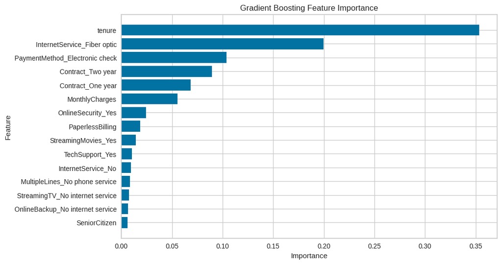

## 6. Evaluating Whether Removing Low-Importance Features Improves Model Performance

```
ROC AUC: 0.8641
```

### Removing near-zero importance features had almost no effect on ROC AUC, indicating that the Gradient Boosting model was already effectively minimizing the influence of weak predictors.

### Because removing low-importance features did not meaningfully improve performance, the original feature set was retained in the final Gradient Boosting model.

## 7. Threshold Selection for the Tuned Model

```
Threshold: 0.2
Recall: 0.890
Precision: 0.483
------------------------------
Threshold: 0.3
Recall: 0.815
Precision: 0.560
------------------------------
Threshold: 0.4
Recall: 0.670
Precision: 0.644
------------------------------
Threshold: 0.5
Recall: 0.531
Precision: 0.695
------------------------------
```

### 8. Gradient Boosting ROC Curve

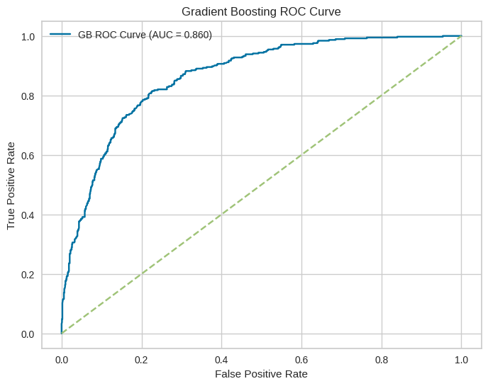

The ROC curve shows strong class separation performance, with the model achieving a ROC AUC score of approximately 0.86. The curve remains well above the random baseline, indicating that the model can effectively distinguish between churn and non-churn customers across different classification thresholds.

## 9. Cross Validation for Gradient Boosting

```
CV ROC AUC Scores:
[0.8477536  0.87194165 0.85718931 0.8626697  0.8461248  0.81973852
 0.85046908 0.83655189 0.84677645 0.84692125]

Mean ROC AUC:
0.8486136247341145

Std:
0.013458030093195506
```

The Gradient Boosting model demonstrated stable performance across 10-fold cross-validation, achieving a mean ROC AUC of approximately 0.85 with low variance between folds (std ≈ 0.013). This suggests that the model generalizes consistently across different subsets of the data and is not overly dependent on a single train-test split.

Although individual fold scores varied slightly, the overall performance remained strong and stable, indicating a robust classification model for churn prediction.

## 10. Summary

The final Gradient Boosting model achieved strong classification performance on the Telco Customer Churn dataset, reaching a ROC AUC score of approximately 0.86. Model tuning focused on optimizing learning_rate and n_estimators, with the best results obtained using a learning rate of 0.05 and 100 estimators.

Threshold analysis demonstrated the trade-off between recall and precision across different decision boundaries. A threshold of 0.4 provided the most balanced business-oriented performance, maintaining solid churn detection while significantly reducing excessive false positive predictions.

Feature importance analysis identified customer tenure, internet service type, payment method, contract duration, and monthly charges as the strongest churn predictors. Removing near-zero importance features produced almost identical evaluation results, suggesting that the Gradient Boosting model was already effectively minimizing the influence of weak predictors.

Finally, 10-fold cross-validation confirmed stable model generalization performance, with consistently strong ROC AUC scores across different data splits.

## 11.Save the Gradiend Boosting model

```
Gradient Boosting model saved.
```

# Compare Logistic Regresion and Gradient Boosting

# ============

The final Gradient Boosting model was selected using a business-oriented evaluation approach focused on balancing churn detection performance and prediction reliability. After tuning learning_rate, n_estimators, and classification thresholds, the final configuration used a learning rate of 0.05, 100 estimators, and a threshold of 0.4.

This setup achieved strong ROC AUC performance while maintaining a balanced trade-off between recall and precision, making the model more practical for real-world churn prediction scenarios where both missed churn cases and excessive false positive alerts carry business costs.

Both the Logistic Regression and Gradient Boosting models were ultimately selected not only based on raw metrics, but also on their practical usefulness, interpretability, and ability to support business decision-making.